# Introduction to Probability for Economics

Ca’ Foscari University of Venice, Bachelor’s Degree Programme in Philosophy, International and Economic Studies.

## Exam

Written Test and Optional Oral Examination.  
The written test consists of 15 multiple-choice questions (Examples of multiple-choice questions are available on Moodle). The duration is 1 hour, and each correct answer is worth 2 points. You are allowed to bring the printed version of the textbook and a calculator.  
The oral examination is mandatory if the written mark is 27/30 or higher.

## Contents

1. Descriptive Statistics
2. Probability and Random Variables
3. Statistical Inference

## Expected learning outcomes

The student will learn, at an introductory level, to summarize and communicate data, compute probabilities, and draw inferences about population parameters.

## Textbook

Agresti, A., Franklin, C.A., and Klingenberg, B. (2017). Statistics: the art and science of learning from data. Pearson, 4th edition (or 2021 5th edition)

## Weekly Contents

### Week 1

TOPIC  
**Descriptive Statistics** (type of variables; frequency table; proportions and percentages; bar plot; histogram; mean, median and mode; outliers; range, variance and standard deviation; percentiles, quartiles and the box-plot; z-scores. The association between two categorical variables; contingency tables; conditional proportions).

EXPECTED LEARNING OUTCOMES  
The student will be able to produce numerical and graphical summaries of data and interpret the results.

TEXTBOOK  
§2.1 - §2.5  
§3.1

EXERCISES  
2.1 Practicing the Basics: 2.1 - 2.9  
2.2 Practicing the Basics: 2.10-2.12, 2.21, 2.26  
2.3 Practicing the Basics: 2.29 - 2.37, 2.39 - 2.45  
2.4 Practicing the Basics: 2.46 - 2.47, 2.57  
2.5 Practicing the Basics: 2.62, 2.64 - 2.71, 2.73 - 2.79  
Chapter problems: 2.90 - 2.92, 2.103, 2.112, 2.119  
3.1 Practicing the Basics: 3.1 - 3.3, 3.5 - 3.9

DATA  
[Titanic](https://github.com/aldosolari/IPE/blob/main/docs/titanic.csv)

IMAGES  
Numerical and Graphical summaries

### Week 2

TOPIC  
**Regression** (the association between two quantitative variables; scatterplot; regression; correlation).  
**Probability** (Random experiment, sample space and random event; axiomatic definition of probability; conditional probability; independence; Bayes theorem).

EXPECTED LEARNING OUTCOMES  
The student will be able to use simple linear regression.  
The student will be able to calculate the probabilities of random events and use Bayes’ rule.

TEXTBOOK  
§3.2 - §3.3  
§5.1 - §5.4

EXERCISES  
3.2 Practicing the Basics: 3.11, 3.14-3.19  
3.3 Practicing the Basics: 3.24 - 3.37  
3.4 Practicing the Basics: 3.45 - 3.48  
5.1 Practicing the Basics: 5.3, 5.6  
5.2 Practicing the Basics: 5.13 - 5.23  
5.3 Practicing the Basics: 5.28 - 5.31  
5.4 Practicing the Basics: 5.47, 5.51, 5.56  
Chapter problems: 5.71 - 5.77, 5.79 - 5.82, 5.86, 5.90, 5.100, 5.101, 5.105 - 5.116

DATA  
[Galton](https://www.randomservices.org/random/data/Galton.html)

IMAGES  
2.6 Pearson Correlation Coefficients of 0  
5.1 Scatter of Sons’ Heights v. Fathers’ Heights  
From Spiegelhalter, D. (2019). The art of statistics: Learning from data. Penguin UK.

### Week 3

TOPIC  
**Random Variables** (Probability distribution of a discrete/continuous random variable; expectation and variance of a discrete/continuous random variables; Bernoulli distribution; binomial distribution; cumulative distribution function; normal distribution. quantile of the standardised normal random variable).

EXPECTED LEARNING OUTCOMES  
The student will be able to use probability distributions for discrete and continuous random variables.

TEXTBOOK  
§6.1 - §6.3

EXERCISES  
6.1 Practicing the Basics: 6.1 - 6.15  
6.3 Practicing the Basics: 6.35 - 6.46; 6.50 - 6.51  
6.2 Practicing the Basics: 6.16 - 6.26  
Chapter problems: 6.53, 6.64, 6.78, 6.80, 6.97

### Week 4

TOPIC  
**Sample Mean and the Central Limit Theorem** (Sampling proportion, sample mean, central limit theorem).

EXPECTED LEARNING OUTCOMES  
The student will be able to approximate the distribution of the sample mean for large samples.

TEXTBOOK  
§1.2  
§7.2 - §7.1

EXERCISES  
1.2 Practicing the Basics: 1.6 - 1.11, 1.13, 1.15  
7.1 Practicing the Basics: 7.4, 7.8, 7.9, 7.11, 7.14  
7.2 Practicing the Basics: 7.21, 7.24 - 7.26.

### Week 5

TOPIC  
**Statistical Inference: Confidence Intervals and Hypothesis Testing** (Point and interval estimation, margin of error, confidence interval for a mean/proportion; estimating the variance; null hypothesis; p-values; significance level and type I error) (Sampling proportion, sample mean, central limit theorem).

EXPECTED LEARNING OUTCOMES  
The student will be able to calculate and interpret the confidence interval for a proportion and for the population mean.  
The student will be able to test hypotheses about the population proportion and mean.

TEXTBOOK  
§8.1 - §8.3  
§9.1 - §9.4

EXERCISES  
8.2 Practicing the Basics: 8.12 - 8.17, 8.19, 8.23  
8.3 Practicing the Basics: 8.29, 8.30  
9.3 Practicing the Basics: 9.28, 9.31, 9.38  
9.4 Practicing the Basics: 9.43, 9.44, 9.48 - 9.52

## Course design

The course requires 150 hours of effort to earn 6 University Credits (CFU), with 30 hours conducted in the classroom.  
The following radar chart defines the percentage weight and time allocation of each learning event within the course.

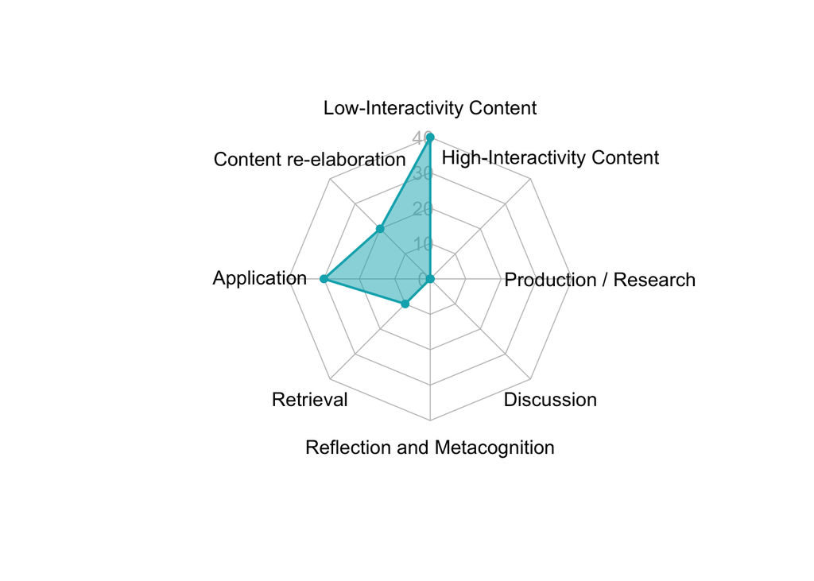

Low interactivity content (40%, 60h): lectures, book studying  
Content re-elaboration (20%, 30h): summaries, outlines  
Application (30%, 45h): exercises  
Retrieval (10%, 15h): quizzes

See the [Smart Learning Design 25](https://www.metid.polimi.it/en/) method for details.

## Acknowledgement

I would like to thank Professor [Stefano Tonnellato](https://www.unive.it/data/persone/5592702) for providing all the course material and the structure of the course. The slides used in the course were generously shared by Stefano, with minor modifications made by me. Any typos or errors that may exist are solely my responsibility.